# Code Portfolio - Week4

HTakano

4/10/2019

#### *- Fundamentals of R markdown -*

#### *- Exploring with other languages -*

### Code Chunks

The “{r}” part can be modified for suitable knit output options. Most common options are displayed as the following code chunk.

```r
x4 <- 2 + 3
```

### Inline Code

```r
bird4 <- 10^6
```

> 10^{6} ounce = 62500 pound

### Python

In order to use Python code in R properly, I needed to install `"reticulate"` package with the CRAN url.

```r
install.packages("reticulate", repos = "http://cran.us.r-project.org")
library(reticulate)
use_python("/usr/local/bin/python")
```

```python
x = 'OMG, Python in R!'
print(x.split(' '))
```

```
## ['OMG,', 'Python', 'in', 'R!']
```

Another example of python chunk with plot.

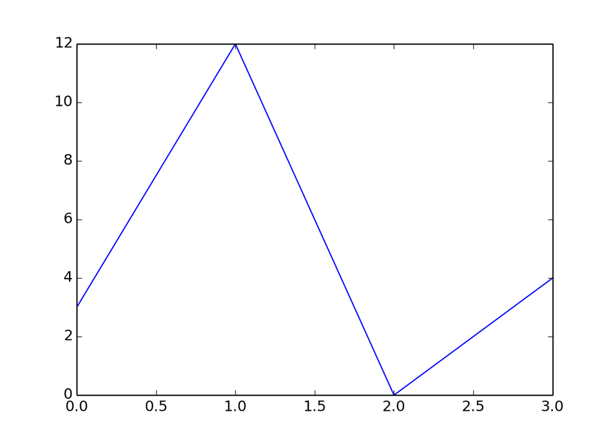

```python
import matplotlib.pyplot as plt
plt.plot([3, 12, 0, 4])
plt.show()
```

### Bash

```bash
ls *Rmd
```

```
## Week4.Rmd
```

### Parameters

R markdown documents can include one or more parameters whose values can be set for rendered reports. The following example is the sea ice data that I used for another project. I have set the parameters as; month = August, pole = North pole, and the year = 1979 with customized color fill.

```r
library(rnoaa)
library(rgdal)
library(ggplot2)
```

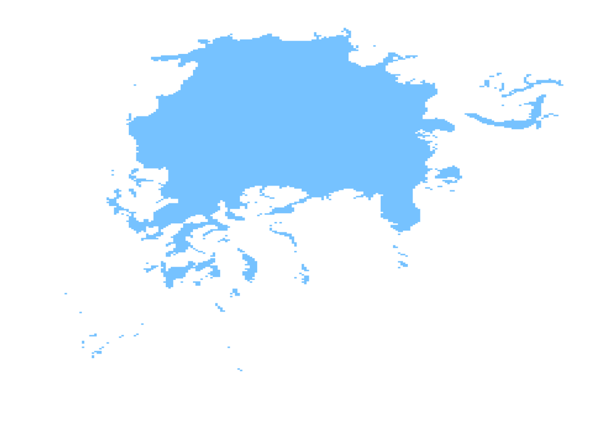

```r
urls <- seaiceeurls(mo = 'Aug', pole = 'N', yr = 1979)
out <- seaice(urls)
ggplot(out, aes(long, lat, group = group)) +
  geom_polygon(fill = "skyblue1") +
  theme_ice()
```

### Tables and kable

R automatically displays data frames and matrixes as defults, but it can be shown with additional formatting.

```r
library(knitr)
kable(iris[5:12, ], caption = "Iris knitr kable")
```

Iris knitr kable

|  | Sepal.Length | Sepal.Width | Petal.Length | Petal.Width | Species |
| --- | --- | --- | --- | --- | --- |
| 5 | 5.0 | 3.6 | 1.4 | 0.2 | setosa |
| 6 | 5.4 | 3.9 | 1.7 | 0.4 | setosa |
| 7 | 4.6 | 3.4 | 1.4 | 0.3 | setosa |
| 8 | 5.0 | 3.4 | 1.5 | 0.2 | setosa |
| 9 | 4.4 | 2.9 | 1.4 | 0.2 | setosa |
| 10 | 4.9 | 3.1 | 1.5 | 0.1 | setosa |
| 11 | 5.4 | 3.7 | 1.5 | 0.2 | setosa |
| 12 | 4.8 | 3.4 | 1.6 | 0.2 | setosa |

### Basics

R markdown text can be formatted as other word documents.

# Header 1

## Header 2

### Header 3

#### Header 4

##### Header 5

1. first
2. second
3. third
- *italics*
- **bold**
- `monospace`
- hyperlink to Google
- Equation $e^{i\pi} + 1 = 0$

### Output Formats

```r
library(rmarkdown)
library(viridis)
```

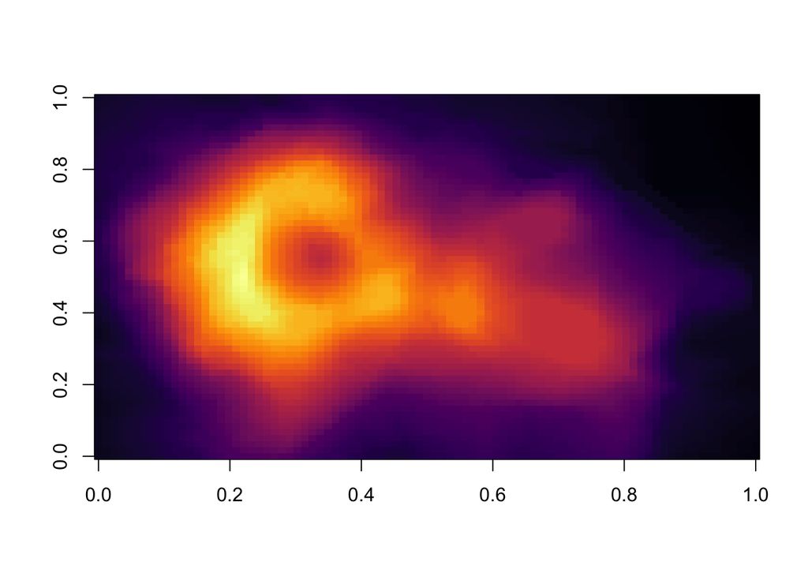

```r
image(volcano, col = viridis(670, option = "B"))
```

============================================